# Theta and DE

Thomas Quinn

March 20, 2017

Here, I explore how differential proportionality (disjointed, $\theta$) relates to differential expression (DE). For this, I use a data set simulated with the R package `polyester`, aligned with Salmon, and mapped with quasi-counts.

Let us import the data and take a random sample of 10,000 genes:

```r
# Import simulated transcriptome and take random sample
txs <- read.csv("/home/thom/Dropbox/R/projects/manuscripts/bench/sim_hv_slQUASIout_counts.csv",
                row.names = 1)
rand <- sample(1:nrow(txs), 10000)
txs <- txs[rand, ]
txs[1:5, 1:5]
```

```
##                 sample_01_quant.sf sample_02_quant.sf sample_03_quant.sf
## ENST00000418525           114.5210             8.0000           70.55140
## ENST00000517482           136.0000            52.0000          172.00000
## ENST00000448084           386.1940            97.5594          160.81700
## ENST00000494508            50.5539           312.6130            1.51839
## ENST00000476592            22.0611            84.7878            4.70017
##                 sample_04_quant.sf sample_05_quant.sf
## ENST00000418525             63.801            21.4362
## ENST00000517482             80.000            35.0000
## ENST00000448084            145.270             0.0000
## ENST00000494508            135.015           339.8370
## ENST00000476592            221.216           105.4700
```

I will remove low counts from the data:

```r
keep <- apply(txs, 1, function(x) sum(x > 20) > 20)
txs <- txs[keep, ]
```

Since this is a simulated data set, we know *a priori* what is differentially expressed. This is available from a separate file:

```r
# Import known annotations
truth <- read.delim("/home/thom/Dropbox/R/projects/manuscripts/bench/hi-var/sim_tx_info.txt", row.names = 1)
rownames(truth) <- unlist(lapply(rownames(truth), function(x) strsplit(x, split = "\\s")[[1]][1]))
true <- truth[rownames(txs), ]
true[1:5, ]
```

```
##                 foldchange.1 foldchange.2 DEstatus.1 DEstatus.2
## ENST00000418525          1.0            1      FALSE      FALSE
## ENST00000517482          1.0            1      FALSE      FALSE
## ENST00000448084          1.0            1      FALSE      FALSE
## ENST00000494508          1.0            1      FALSE      FALSE
## ENST00000476592          0.5            1       TRUE      FALSE
```

We will calculate disjointed proportionality on the sample.

```r
library(propriety)
pd.tx <- propd(t(txs), group = c(rep("A", 20), rep("B", 20)))
```

```
## Alert: Replacing 0s in "count matrix" with 1.
```

```
## Alert: 0 counts can distort log-ratio means.
```

Let us define a few functions for DE benchmarking. The first, `calcStats`, calculates precision and recall. The second, `simpleEdger`, runs a basic exact test using the DE software `edgeR`:

```r
calcStats <- function(obs, ref, what){

  all <- rownames(ref)
  tru <- rownames(ref)[ref$DEstatus.1]

  observed <- all %in% obs
  actual <- all %in% tru

  conf <- table(observed, actual)
  if(what == "precision"){
    out <- conf["TRUE", "TRUE"] / (conf["TRUE", "FALSE"] + conf["TRUE", "TRUE"])
  }else if(what == "recall"){
    out <- conf["TRUE", "TRUE"] / (conf["FALSE", "TRUE"] + conf["TRUE", "TRUE"])
  }
  return(out)
}

simpleEdger <- function(ct, group){

  library(edgeR)
  y <- DGEList(counts = ct, group = group)
  y <- calcNormFactors(y)
  y <- estimateCommonDisp(y)
  y <- estimateTagwiseDisp(y)
  et <- exactTest(y)
  tt <- as.data.frame(topTags(et, n = nrow(et)))
  deGenes <- rownames(tt)[tt$FDR < .05]
  plotSmear(et, de.tags = deGenes, cex = 0.5)
  return(deGenes)
}
```

Let us see how well $\theta$ selects for DE transcripts:

```r
metrix <- lapply(c(50, 100, 200, 400, 800, 1600),
                 function(x){

                   check <- shale(pd.tx, cutoff = x, prompt = FALSE)
                   top <- union(check$PartnerName, check$PairName)
                   data.frame(calcStats(top, true, "precision"),
                              calcStats(top, true, "recall"))
                 })
do.call("rbind", metrix)
```

```
##   calcStats.top..true...precision.. calcStats.top..true...recall..
## 1                         0.9811321                     0.01802426
## 2                         0.9756098                     0.02772964
## 3                         0.9485294                     0.04471404
## 4                         0.9261084                     0.06516464
## 5                         0.9071856                     0.10502600
## 6                         0.8446602                     0.15077990
```

Not bad! How does this compare to `edgeR`?

```r
de <- simpleEdger(txs, group = c(rep("A", 20), rep("B", 20)))
```

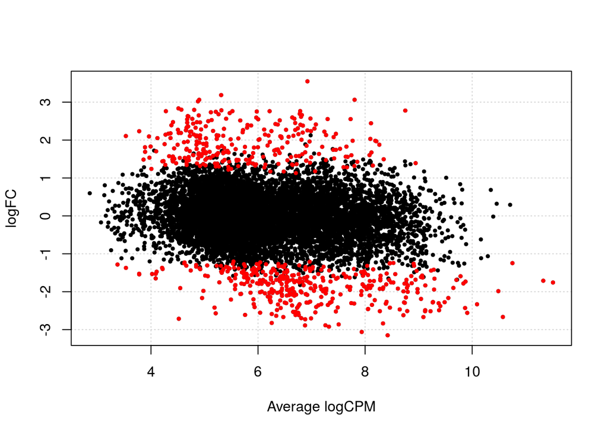

```r
calcStats(de, true, "precision")
```

```
## [1] 0.9555896
```

```r
calcStats(de, true, "recall")
```

```
## [1] 0.2162912
```

Let us view the network to see which nodes (transcripts) get the wrong DE calls:

```
## Visualizing disjointed proportionality (theta_d):
```

```
## Red: Pair has higher LRM in group A than in group B
```

```
## Blue: Pair has lower LRM in group A than in group B
```

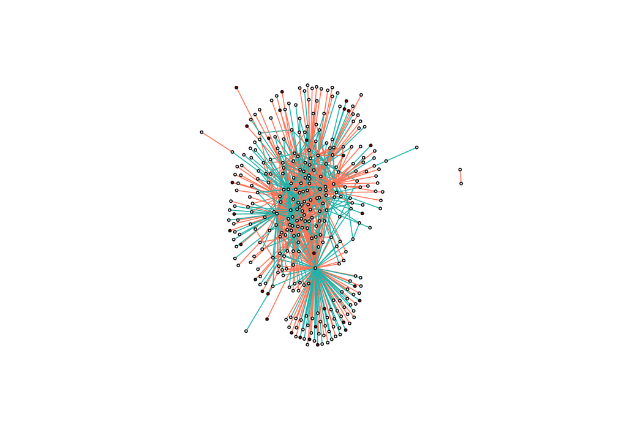

```r
# check <- shale(pd.tx, cutoff = 8000, prompt = FALSE)
# top <- union(check$PartnerName, check$PairName)
# table(true$foldchange.1)
# table(true[top, "foldchange.1"])
g <- plot(pd.tx, cutoff = 800, prompt = FALSE, col1 = rownames(true[true$foldchange.1 == 1,]))
```

Interestingly, most of the wrong DE calls occur in peripheral nodes with low connectivity. Does removing transcripts with only one connection improve precision?

```r
metrix <- lapply(c(50, 100, 200, 400, 800, 1600, 3200),
                 function(x){

                   g <- plot(pd.tx, cutoff = x, prompt = FALSE, col1 = rownames(true[true$foldchange.1 == 1,]))
                   d <- sort(igraph::degree(g), decreasing = TRUE)
                   top <- names(d[d != 1])
                   data.frame(calcStats(top, true, "precision"),
                              calcStats(top, true, "recall"))
                 })
do.call("rbind", metrix)
```

```
##   calcStats.top..true...precision.. calcStats.top..true...recall..
## 1                         1.0000000                    0.005545927
## 2                         1.0000000                    0.011785095
## 3                         1.0000000                    0.020450607
## 4                         1.0000000                    0.031889081
## 5                         0.9820359                    0.056845754
## 6                         0.9468085                    0.092547660
## 7                         0.8795699                    0.141767764
```

What about when we remove transcripts with less than 3 connections?

```r
metrix <- lapply(c(50, 100, 200, 400, 800, 1600, 3200),
                 function(x){

                   g <- plot(pd.tx, cutoff = x, prompt = FALSE, col1 = rownames(true[true$foldchange.1 == 1,]))
                   d <- sort(igraph::degree(g), decreasing = TRUE)
                   top <- names(d[d > 2])
                   data.frame(calcStats(top, true, "precision"),
                              calcStats(top, true, "recall"))
                 })
do.call("rbind", metrix)
```

```
##   calcStats.top..true...precision.. calcStats.top..true...recall..
## 1                         1.0000000                    0.003119584
## 2                         1.0000000                    0.006239168
## 3                         1.0000000                    0.011438475
## 4                         1.0000000                    0.023570191
## 5                         0.9729730                    0.037435009
## 6                         0.9708738                    0.069324090
## 7                         0.9161850                    0.109878683
```

Let us just consider transcripts in the top 30% as ranked by connectivity:

```r
metrix <- lapply(c(50, 100, 200, 400, 800, 1600, 3200),
                 function(x){

                   g <- plot(pd.tx, cutoff = x, prompt = FALSE, col1 = rownames(true[true$foldchange.1 == 1,]))
                   d <- sort(igraph::degree(g), decreasing = TRUE)
                   top <- names(d[1:(floor(length(d)*.3))])
                   data.frame(calcStats(top, true, "precision"),
                              calcStats(top, true, "recall"))
                 })
do.call("rbind", metrix)
```

```
##   calcStats.top..true...precision.. calcStats.top..true...recall..
## 1                         1.0000000                    0.005199307
## 2                         1.0000000                    0.008318891
## 3                         1.0000000                    0.013864818
## 4                         1.0000000                    0.020797227
## 5                         0.9800000                    0.033968804
## 6                         0.9935065                    0.053032929
## 7                         0.9563492                    0.083535529
```